# Report of SpaceShip Kaggle Competition

Lindolfo Cavalcanti

2024-07

# Introduction

The Spaceship Titanic competition on Kaggle presents an intriguing challenge inspired by the classic Titanic disaster but set in a futuristic context. Participants are tasked with predicting whether passengers were transported to an alternate dimension during an interstellar voyage. The competition’s dataset includes a variety of features about the passengers, such as their demographics, cabin assignments, and spending habits on board.

This report aims to provide a comprehensive analysis of the Spaceship Titanic dataset, encompassing data exploration, visualization, and predictive modeling. By leveraging these techniques, I seek to uncover patterns and insights that can enhance our understanding of the factors influencing passenger transportation.

## Objectives

# Load Package and data

In this section, I will first load the packages and data that I utilized in this report.

```r
library(tidyverse)
library(randomForest)
library(dlookr)
library(flextable)
library(esquisse)
library(ggThemeAssist)
```

```r
train_space = read.csv("/home/lindo/Documents/Kaggle/SpaceshipKaggle/trainspace.csv")
test_space = read.csv("/home/lindo/Documents/Kaggle/SpaceshipKaggle/testspace.csv")
```

## Packages Overview

**tidyverse:**

A collection of R packages designed for data science that Facilitates workflow for data manipulation, exploration, and visualization.

**randomForest:**

An implementation of the Random Forest algorithm, useful for both classification and regression tasks. Helps build an ensemble model that improves prediction accuracy by averaging multiple decision trees.

**dlookr:**

A package for data diagnosis, transformation, and visualization. Assists in identifying missing values, outliers, and understanding the distribution of data.

**flextable:**

Provides a straightforward way to create and customize tables in R, suitable for reporting and documentation. Enhances the presentation of data summaries and model results.

**esquisse:**

An interactive tool that simplifies the process of creating ggplot2 visualizations without writing extensive code. Enables users to drag-and-drop variables to create plots, making data visualization more accessible.

**ggThemeAssist:**

A graphical user interface add-in for customizing ggplot2 themes. Allows for easy adjustment of plot aesthetics to improve the visual appeal of data visualizations.

# Create a New Dataframe with train and test

Creating a new dataframe by combining specific columns from existing data with newly created columns is a fundamental step in data preprocessing. This process allows us to customize our data structure to better suit the needs of subsequent analysis, visualization, and modeling tasks. By thoughtfully combining relevant data, we can enhance the clarity and usefulness of our dataset.

```r
test_space$Transported = NA
train_space$IsTrain = TRUE
test_space$IsTrain = FALSE
full_space = rbind(train_space, test_space)
```

```r
full_space %>% glimpse()
```

```
## Rows: 12,970
## Columns: 15
## $ PassengerId  <chr> "0001_01", "0002_01", "0003_01", "0003_02", "0004_01", "0…
## $ HomePlanet   <chr> "Europa", "Earth", "Europa", "Europa", "Earth", "Earth", …
## $ CryoSleep    <chr> "False", "False", "False", "False", "False", "False", "Fa…
## $ Cabin        <chr> "B/0/P", "F/0/S", "A/0/S", "A/0/S", "F/1/S", "F/0/P", "F/…
## $ Destination  <chr> "TRAPPIST-1e", "TRAPPIST-1e", "TRAPPIST-1e", "TRAPPIST-1e…
## $ Age          <dbl> 39, 24, 58, 33, 16, 44, 26, 28, 35, 14, 34, 45, 32, 48, 2…
## $ VIP          <chr> "False", "False", "True", "False", "False", "False", "Fal…
## $ RoomService  <dbl> 0, 109, 43, 0, 303, 0, 42, 0, 0, 0, 0, 39, 73, 719, 8, 32…
## $ FoodCourt    <dbl> 0, 9, 3576, 1283, 70, 483, 1539, 0, 785, 0, 0, 7295, 0, 1…
## $ ShoppingMall <dbl> 0, 25, 0, 371, 151, 0, 3, 0, 17, 0, NA, 589, 1123, 65, 12…
## $ Spa          <dbl> 0, 549, 6715, 3329, 565, 291, 0, 0, 216, 0, 0, 110, 0, 0,…
## $ VRDeck       <dbl> 0, 44, 49, 193, 2, 0, 0, NA, 0, 0, 0, 124, 113, 24, 7, 0,…
## $ Name         <chr> "Maham Ofracculy", "Juanna Vines", "Altark Susent", "Sola…
## $ Transported  <chr> "False", "True", "False", "False", "True", "True", "True"…
## $ IsTrain      <lgl> TRUE, TRUE, TRUE, TRUE, TRUE, TRUE, TRUE, TRUE, TRUE, TRU…
```

# Exploring Data

Now we need to take a look on our data and decide what to do with it to get our prediction and plots.

```r
diagnose(full_space) %>% flextable() %>% theme_apa()
```

| variables | types | missing_count | missing_percent | unique_count | unique_rate |
| --- | --- | --- | --- | --- | --- |
| PassengerId | character | 0 | 0.00 | 12,970 | 1.00 |
| HomePlanet | character | 0 | 0.00 | 4 | 0.00 |
| CryoSleep | character | 0 | 0.00 | 3 | 0.00 |
| Cabin | character | 0 | 0.00 | 9,826 | 0.76 |
| Destination | character | 0 | 0.00 | 4 | 0.00 |
| Age | numeric | 270 | 2.08 | 81 | 0.01 |
| VIP | character | 0 | 0.00 | 3 | 0.00 |
| RoomService | numeric | 263 | 2.03 | 1,579 | 0.12 |
| FoodCourt | numeric | 289 | 2.23 | 1,954 | 0.15 |
| ShoppingMall | numeric | 306 | 2.36 | 1,368 | 0.11 |
| Spa | numeric | 284 | 2.19 | 1,680 | 0.13 |
| VRDeck | numeric | 268 | 2.07 | 1,643 | 0.13 |
| Name | character | 0 | 0.00 | 12,630 | 0.97 |
| Transported | character | 4,277 | 32.98 | 3 | 0.00 |
| IsTrain | logical | 0 | 0.00 | 2 | 0.00 |

First, we have 12970 rows summing train and test data sets. We have 15 variables (columns). Most of then are registered as character but it should be factor (HomePlanet, CryoSleep, Destination, VIP, Transported). So we need to deal with it before starting our analysis.

Besides, we have 7 columns with NA values. Transported is the variable we want to predict, so we don’t need to worry about it now. But we should take a look on Age, RoomService, FoodCourt, ShoppingMall, Spa and VRDeck.

## Age

```r
full_space %>% diagnose_numeric(Age) %>% flextable() %>% theme_apa()
```

| variables | min | Q1 | mean | median | Q3 | max | zero | minus | outlier |
| --- | --- | --- | --- | --- | --- | --- | --- | --- | --- |
| Age | 0.00 | 19.00 | 28.77 | 27.00 | 38.00 | 79.00 | 260 | 0 | 110 |

The median and mean in age are similar, so we should not have any problem in transform the NA values in the median. I must inform, this report will focus mainly in the data visualization and descriptive statistics, so the prediction is not our main objective. If you want to have a better model to predict the transported people, I suggest a more sophisticated technique to deal with these NA values.

```r
full_space$Age[is.na(full_space$Age)] = median(full_space$Age, na.rm = TRUE)
```

```r
full_space$Age %>% is.na() %>% sum()
```

```
## [1] 0
```

Ok, we took care of the NA values in Age. Now, we should take a look in the distribution of this variable and test the normality.

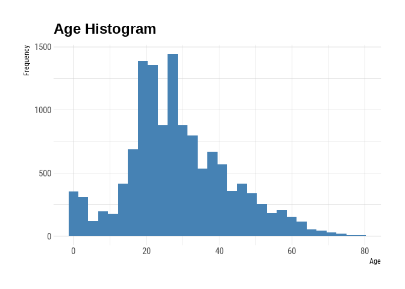

```r
ggplot(full_space) +
 aes(x = Age) +
 geom_histogram(bins = 30L, fill = "#4682B4") +
 labs(x = "Age", y = "Frequency",
 title = "Age Histogram") +
 hrbrthemes::theme_ipsum_rc() + theme(plot.subtitle = element_text(family = "sans"),
    plot.caption = element_text(family = "sans"),
    axis.title = element_text(family = "sans"),
    axis.text = element_text(size = 12),
    plot.title = element_text(family = "sans")) + theme(axis.title = element_text(size = 12))
```

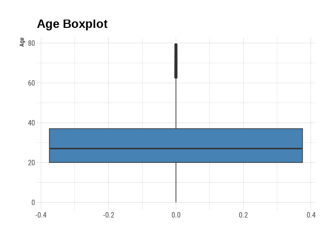

```r
ggplot(full_space, aes(y = Age)) +
  geom_boxplot(fill = "#4682B4") +
  labs(y = "Age",
       title = "Age Boxplot") +
  hrbrthemes::theme_ipsum_rc() +
  theme(
    plot.subtitle = element_text(family = "sans"),
    plot.caption = element_text(family = "sans"),
    axis.title = element_text(family = "sans"),
    axis.text = element_text(size = 12),
    plot.title = element_text(family = "sans"),
  )
```

```r
full_space %>% diagnose_outlier(Age) %>% flextable() %>% theme_apa()
```

| variables | outliers_cnt | outliers_ratio | outliers_mean | with_mean | without_mean |
| --- | --- | --- | --- | --- | --- |
| Age | 237 | 1.83 | 67.47 | 28.74 | 28.01 |

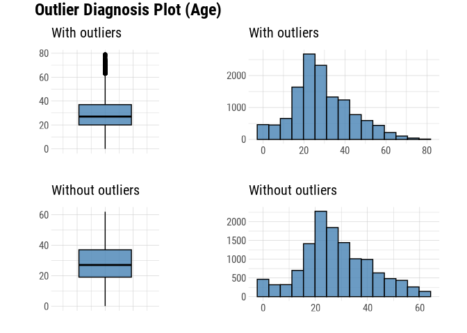

```r
full_space %>% plot_outlier(Age)
```

According to the histogram and boxplot, we have, in general a normal distributed data in the variable Age. We just need to pay attention in the people between 60 and 80 years old. These people seem to unbalance the distribution and create outliers. But, as we can see in the descriptive statistics of Age’s outliers, it does not significantly interfere the distribution.

## RoomService, FoodCourt, ShoppingMall, Spa and VRDeck

Now, we must investigate the others variables. These variables represent how much mony people spent during their time in the spaceship. So, we will analyse all of them at the same time

```r
full_space %>% diagnose_numeric(RoomService, FoodCourt, ShoppingMall, Spa, VRDeck) %>% flextable() %>% theme_apa()
```

| variables | min | Q1 | mean | median | Q3 | max | zero | minus | outlier |
| --- | --- | --- | --- | --- | --- | --- | --- | --- | --- |
| RoomService | 0.00 | 0.00 | 222.90 | 0.00 | 49.00 | 14,327.00 | 8,303 | 0 | 2,758 |
| FoodCourt | 0.00 | 0.00 | 451.96 | 0.00 | 77.00 | 29,813.00 | 8,146 | 0 | 2,720 |
| ShoppingMall | 0.00 | 0.00 | 174.91 | 0.00 | 29.00 | 23,492.00 | 8,331 | 0 | 2,708 |
| Spa | 0.00 | 0.00 | 308.48 | 0.00 | 57.00 | 22,408.00 | 7,935 | 0 | 2,674 |
| VRDeck | 0.00 | 0.00 | 306.79 | 0.00 | 42.00 | 24,133.00 | 8,252 | 0 | 2,697 |

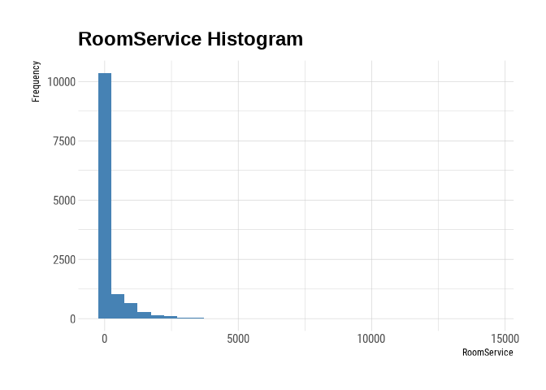

```r
ggplot(full_space) +
 aes(x = RoomService) +
 geom_histogram(bins = 30L, fill = "#4682B4") +
 labs(x = "RoomService", y = "Frequency",
 title = "RoomService Histogram") +
 hrbrthemes::theme_ipsum_rc() + theme(plot.subtitle = element_text(family = "sans"),
    plot.caption = element_text(family = "sans"),
    axis.title = element_text(family = "sans"),
    axis.text = element_text(size = 12),
    plot.title = element_text(family = "sans")) + theme(axis.title = element_text(size = 12))
```

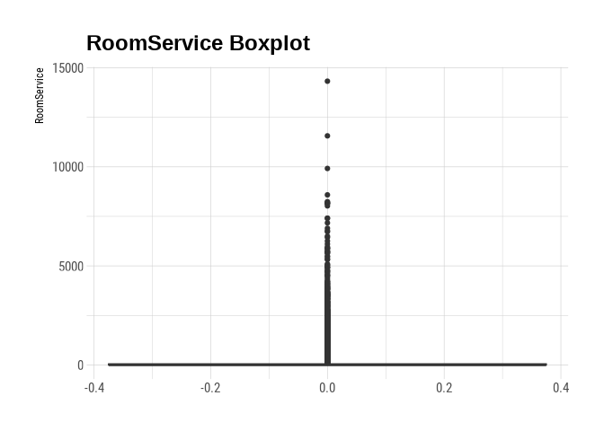

```r
ggplot(full_space, aes(y = RoomService)) +
  geom_boxplot(fill = "#4682B4") +
  labs(y = "RoomService",
       title = "RoomService Boxplot") +
  hrbrthemes::theme_ipsum_rc() +
  theme(
    plot.subtitle = element_text(family = "sans"),
    plot.caption = element_text(family = "sans"),
    axis.title = element_text(family = "sans"),
    axis.text = element_text(size = 12),
    plot.title = element_text(family = "sans"),
  )
```

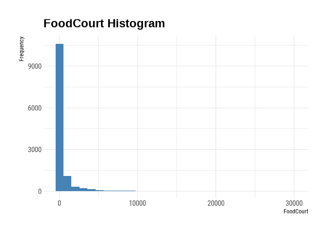

```r
ggplot(full_space) +
 aes(x = FoodCourt) +
 geom_histogram(bins = 30L, fill = "#4682B4") +
 labs(x = "FoodCourt", y = "Frequency",
 title = "FoodCourt Histogram") +
 hrbrthemes::theme_ipsum_rc() + theme(plot.subtitle = element_text(family = "sans"),
    plot.caption = element_text(family = "sans"),
    axis.title = element_text(family = "sans"),
    axis.text = element_text(size = 12),
    plot.title = element_text(family = "sans")) + theme(axis.title = element_text(size = 12))
```

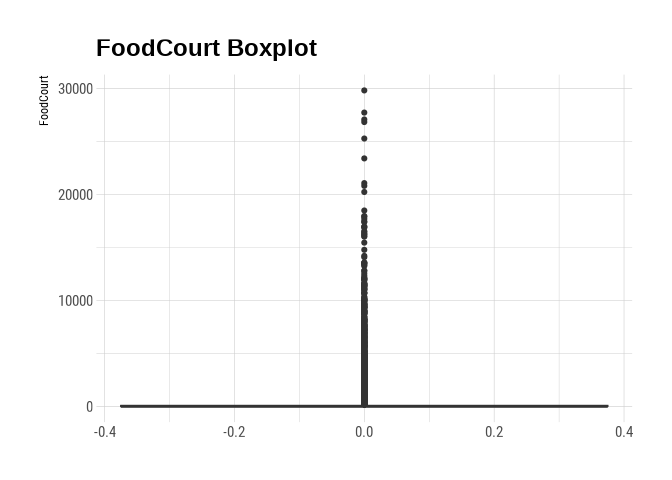

```r
ggplot(full_space, aes(y = FoodCourt)) +
  geom_boxplot(fill = "#4682B4") +
  labs(y = "FoodCourt",
       title = "FoodCourt Boxplot") +
  hrbrthemes::theme_ipsum_rc() +
  theme(
    plot.subtitle = element_text(family = "sans"),
    plot.caption = element_text(family = "sans"),
    axis.title = element_text(family = "sans"),
    axis.text = element_text(size = 12),
    plot.title = element_text(family = "sans"),
  )
```

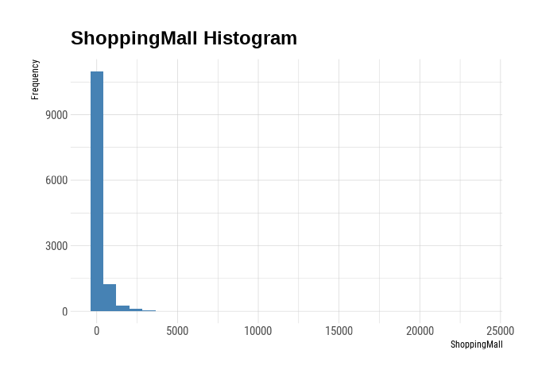

```r
ggplot(full_space) +
 aes(x = ShoppingMall) +
 geom_histogram(bins = 30L, fill = "#4682B4") +
 labs(x = "ShoppingMall", y = "Frequency",
 title = "ShoppingMall Histogram") +
 hrbrthemes::theme_ipsum_rc() + theme(plot.subtitle = element_text(family = "sans"),
    plot.caption = element_text(family = "sans"),
    axis.title = element_text(family = "sans"),
    axis.text = element_text(size = 12),
    plot.title = element_text(family = "sans")) + theme(axis.title = element_text(size = 12))
```

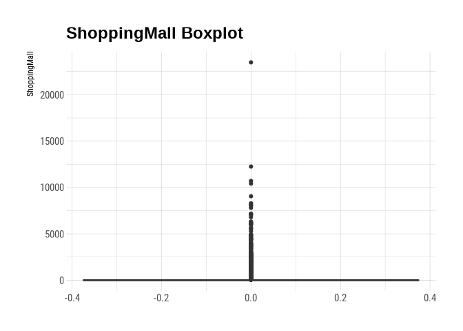

```r
ggplot(full_space, aes(y = ShoppingMall)) +
  geom_boxplot(fill = "#4682B4") +
  labs(y = "ShoppingMall",
       title = "ShoppingMall Boxplot") +
  hrbrthemes::theme_ipsum_rc() +
  theme(
    plot.subtitle = element_text(family = "sans"),
    plot.caption = element_text(family = "sans"),
    axis.title = element_text(family = "sans"),
    axis.text = element_text(size = 12),
    plot.title = element_text(family = "sans"),
  )
```

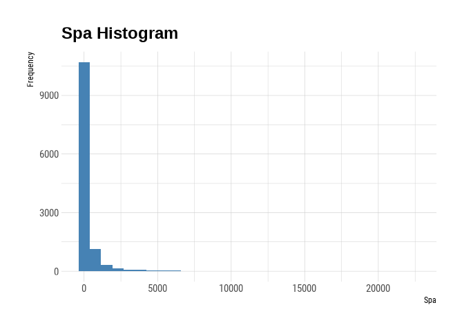

```r
ggplot(full_space) +
 aes(x = Spa) +
 geom_histogram(bins = 30L, fill = "#4682B4") +
 labs(x = "Spa", y = "Frequency",
 title = "Spa Histogram") +
 hrbrthemes::theme_ipsum_rc() + theme(plot.subtitle = element_text(family = "sans"),
    plot.caption = element_text(family = "sans"),
    axis.title = element_text(family = "sans"),
    axis.text = element_text(size = 12),
    plot.title = element_text(family = "sans")) + theme(axis.title = element_text(size = 12))
```

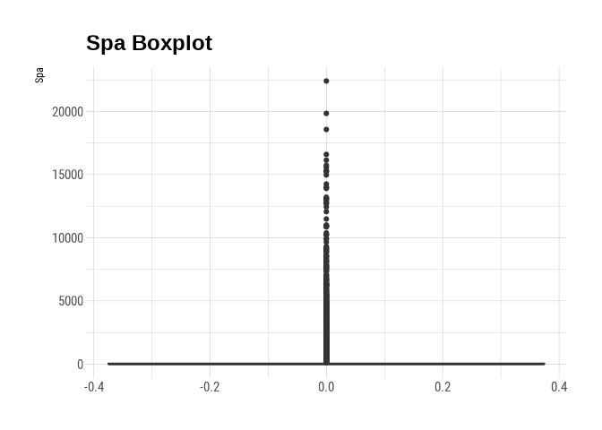

```r
ggplot(full_space, aes(y = Spa)) +
  geom_boxplot(fill = "#4682B4") +
  labs(y = "Spa",
       title = "Spa Boxplot") +
  hrbrthemes::theme_ipsum_rc() +
  theme(
    plot.subtitle = element_text(family = "sans"),
    plot.caption = element_text(family = "sans"),
    axis.title = element_text(family = "sans"),
    axis.text = element_text(size = 12),
    plot.title = element_text(family = "sans"),
  )
```

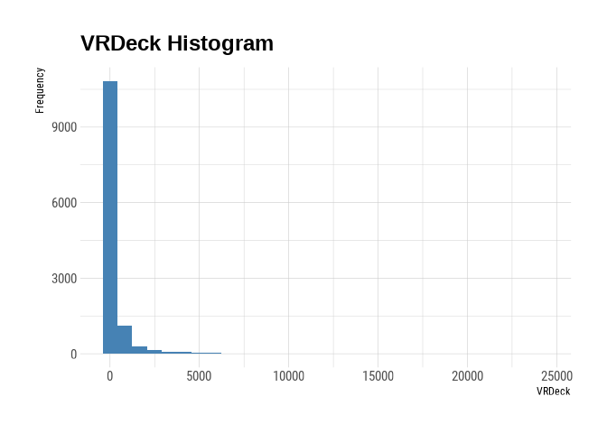

```r
ggplot(full_space) +
 aes(x = VRDeck) +
 geom_histogram(bins = 30L, fill = "#4682B4") +
 labs(x = "VRDeck", y = "Frequency",
 title = "VRDeck Histogram") +
 hrbrthemes::theme_ipsum_rc() + theme(plot.subtitle = element_text(family = "sans"),
    plot.caption = element_text(family = "sans"),
    axis.title = element_text(family = "sans"),
    axis.text = element_text(size = 12),
    plot.title = element_text(family = "sans")) + theme(axis.title = element_text(size = 12))
```

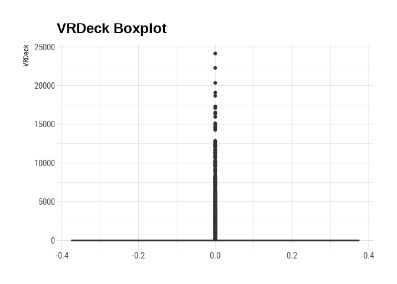

```r
ggplot(full_space, aes(y = VRDeck)) +
  geom_boxplot(fill = "#4682B4") +
  labs(y = "VRDeck",
       title = "VRDeck Boxplot") +
  hrbrthemes::theme_ipsum_rc() +
  theme(
    plot.subtitle = element_text(family = "sans"),
    plot.caption = element_text(family = "sans"),
    axis.title = element_text(family = "sans"),
    axis.text = element_text(size = 12),
    plot.title = element_text(family = "sans"),
  )
```

```r
full_space %>% diagnose_outlier(RoomService, FoodCourt, ShoppingMall, Spa, VRDeck) %>% flextable() %>% theme_apa()
```

| variables | outliers_cnt | outliers_ratio | outliers_mean | with_mean | without_mean |
| --- | --- | --- | --- | --- | --- |
| RoomService | 2,758 | 21.26 | 1,008.23 | 222.90 | 5.19 |
| FoodCourt | 2,720 | 20.97 | 2,075.90 | 451.96 | 8.52 |
| ShoppingMall | 2,708 | 20.88 | 806.18 | 174.91 | 3.20 |
| Spa | 2,674 | 20.62 | 1,436.50 | 308.48 | 7.20 |
| VRDeck | 2,697 | 20.79 | 1,426.73 | 306.79 | 4.89 |

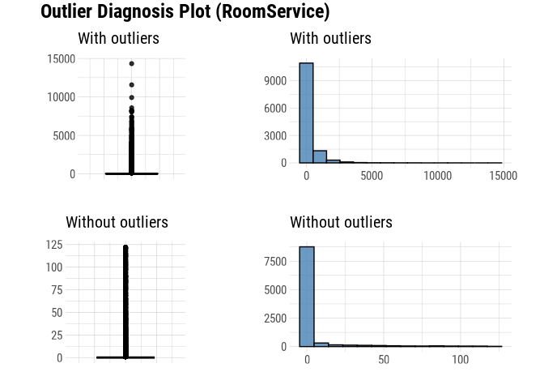

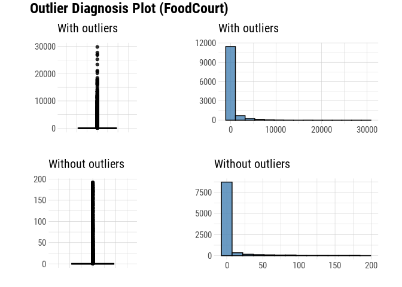

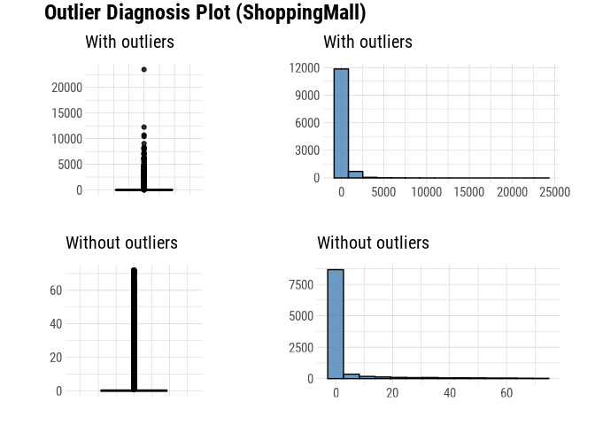

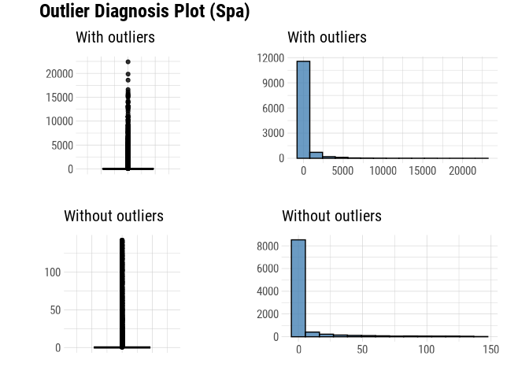

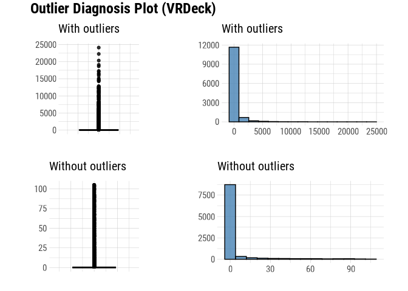

```r
full_space %>% plot_outlier(RoomService, FoodCourt, ShoppingMall, Spa, VRDeck)
```

As observed from the initial analysis, the results for various spending categories on the spaceship are quite different from those related to age. This discrepancy is likely due to the fact that these categories represent different aspects of money spent on the spaceship, which can vary significantly. To address this issue, we should combining these similar spending categories into a new aggregated category. This approach will help us simplify the analysis and draw more meaningful insights by reducing the variability introduced by multiple related features.

But, before doing that let’s deal with the missing values.

```r
median_na_solution = function(x) {
    x[is.na({{x}})] = median({{x}}, na.rm = TRUE)
    return(x)
}

    full_space$RoomService[is.na(full_space$RoomService)] = median_na_solution(full_space$RoomService)
    full_space$FoodCourt[is.na(full_space$FoodCourt)] = median_na_solution(full_space$FoodCourt)
    full_space$ShoppingMall[is.na(full_space$ShoppingMall)] = median_na_solution(full_space$ShoppingMall)
    full_space$Spa[is.na(full_space$Spa)] = median_na_solution(full_space$Spa)
    full_space$VRDeck[is.na(full_space$VRDeck)] = median_na_solution(full_space$VRDeck)
```

```r
full_space %>% is.na() %>% colSums()
```

```
##  PassengerId   HomePlanet    CryoSleep        Cabin  Destination          Age
##            0            0            0            0            0            0
##          VIP  RoomService    FoodCourt ShoppingMall          Spa       VRDeck
##            0            0            0            0            0            0
##         Name  Transported      IsTrain
##            0         4277            0
```

Let us proceed to unify them now.

```r
monetary_columns <- c("RoomService", "FoodCourt", "ShoppingMall", "Spa", "VRDeck")

full_space <- full_space %>%
  mutate(TotalSpending = rowSums(select(., all_of(monetary_columns))))
```

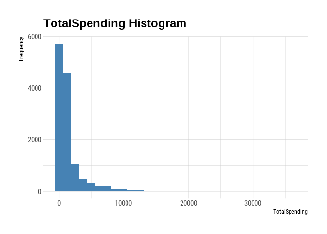

```r
ggplot(full_space) +
 aes(x = TotalSpending) +
 geom_histogram(bins = 30L, fill = "#4682B4") +
 labs(x = "TotalSpending", y = "Frequency",
 title = "TotalSpending Histogram") +
 hrbrthemes::theme_ipsum_rc() + theme(plot.subtitle = element_text(family = "sans"),
    plot.caption = element_text(family = "sans"),
    axis.title = element_text(family = "sans"),
    axis.text = element_text(size = 12),
    plot.title = element_text(family = "sans")) + theme(axis.title = element_text(size = 12))
```

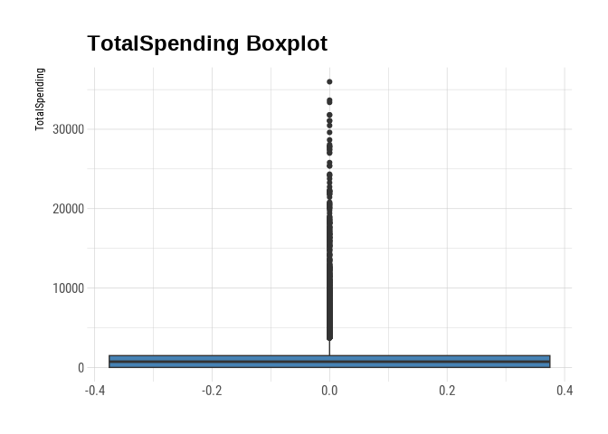

```r
ggplot(full_space, aes(y = TotalSpending)) +
  geom_boxplot(fill = "#4682B4") +
  labs(y = "TotalSpending",
       title = "TotalSpending Boxplot") +
  hrbrthemes::theme_ipsum_rc() +
  theme(
    plot.subtitle = element_text(family = "sans"),
    plot.caption = element_text(family = "sans"),
    axis.title = element_text(family = "sans"),
    axis.text = element_text(size = 12),
    plot.title = element_text(family = "sans"),
  )
```

```r
full_space %>% diagnose_outlier(TotalSpending) %>% flextable() %>% theme_apa()
```

| variables | outliers_cnt | outliers_ratio | outliers_mean | with_mean | without_mean |
| --- | --- | --- | --- | --- | --- |
| TotalSpending | 1,345 | 10.37 | 7,964.49 | 1,463.07 | 710.86 |

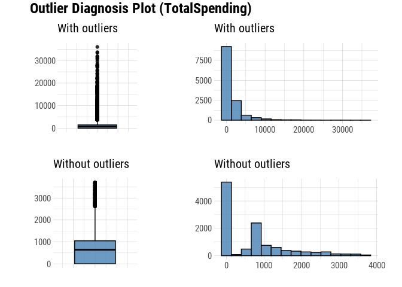

```r
full_space %>% plot_outlier(TotalSpending)
```

Now, we should remove the columns that the summed and the columns that are useless to our analysis and prediction.

```r
full_space$RoomService = NULL
full_space$FoodCourt = NULL
full_space$Spa = NULL
full_space$VRDeck = NULL
full_space$ShoppingMall = NULL
full_space$Name = NULL # useless
```

To finish to clean our data, we should transform de classes of the variables to the right one. In this case, there some columns that we need to transform in factor. Let’s do this now.

```r
# Convert all character columns to factors, except for 'Cabin' and 'PassengerId'
full_space <- full_space %>%
  mutate(across(where(is.character), as.factor)) %>%
  mutate(Cabin = as.character(Cabin),
         PassengerId = as.character(PassengerId))

str(full_space)
```

```
## 'data.frame':    12970 obs. of  10 variables:
##  $ PassengerId  : chr  "0001_01" "0002_01" "0003_01" "0003_02" ...
##  $ HomePlanet   : Factor w/ 4 levels "","Earth","Europa",..: 3 2 3 3 2 2 2 2 2 3 ...
##  $ CryoSleep    : Factor w/ 3 levels "","False","True": 2 2 2 2 2 2 2 3 2 3 ...
##  $ Cabin        : chr  "B/0/P" "F/0/S" "A/0/S" "A/0/S" ...
##  $ Destination  : Factor w/ 4 levels "","55 Cancri e",..: 4 4 4 4 4 3 4 4 4 2 ...
##  $ Age          : num  39 24 58 33 16 44 26 28 35 14 ...
##  $ VIP          : Factor w/ 3 levels "","False","True": 2 2 3 2 2 2 2 2 2 2 ...
##  $ Transported  : Factor w/ 2 levels "False","True": 1 2 1 1 2 2 2 2 2 2 ...
##  $ IsTrain      : logi  TRUE TRUE TRUE TRUE TRUE TRUE ...
##  $ TotalSpending: num  0 736 10383 5176 1091 ...
```

Ok, we finished to clean our data. Let’go to the prediction.

# Prediction

First, we need to separate our data set in train and test data. Let’s do this.

```r
train_space = full_space[full_space$IsTrain == TRUE,]
train_space$IsTrain = NULL

test_space = full_space[full_space$IsTrain == FALSE,]
test_space$IsTrain = NULL
```

```r
diagnose(train_space) %>% flextable() %>% theme_apa()
```

| variables | types | missing_count | missing_percent | unique_count | unique_rate |
| --- | --- | --- | --- | --- | --- |
| PassengerId | character | 0 | 0.00 | 8,693 | 1.00 |
| HomePlanet | factor | 0 | 0.00 | 4 | 0.00 |
| CryoSleep | factor | 0 | 0.00 | 3 | 0.00 |
| Cabin | character | 0 | 0.00 | 6,561 | 0.75 |
| Destination | factor | 0 | 0.00 | 4 | 0.00 |
| Age | numeric | 0 | 0.00 | 80 | 0.01 |
| VIP | factor | 0 | 0.00 | 3 | 0.00 |
| Transported | factor | 0 | 0.00 | 2 | 0.00 |
| TotalSpending | numeric | 0 | 0.00 | 2,441 | 0.28 |

```r
diagnose(test_space) %>% flextable() %>% theme_apa()
```

| variables | types | missing_count | missing_percent | unique_count | unique_rate |
| --- | --- | --- | --- | --- | --- |
| PassengerId | character | 0 | 0.00 | 4,277 | 1.00 |
| HomePlanet | factor | 0 | 0.00 | 4 | 0.00 |
| CryoSleep | factor | 0 | 0.00 | 3 | 0.00 |
| Cabin | character | 0 | 0.00 | 3,266 | 0.76 |
| Destination | factor | 0 | 0.00 | 4 | 0.00 |
| Age | numeric | 0 | 0.00 | 79 | 0.02 |
| VIP | factor | 0 | 0.00 | 3 | 0.00 |
| Transported | factor | 4,277 | 100.00 | 1 | 0.00 |
| TotalSpending | numeric | 0 | 0.00 | 1,482 | 0.35 |

Perfect! Now we can build our model.

## Build the model

```r
formula_space = "Transported ~ HomePlanet + CryoSleep + Cabin + Destination + Age + VIP + TotalSpending"
formula_space = as.formula(formula_space)


model_space = randomForest(formula = formula_space, data = train_space, ntree = 500, mtry = 3, nodesize = 0.01 * nrow(train_space))
```

Now we must predict.

```r
space_prediction = predict(model_space, newdata = test_space)
table(space_prediction)
```

```
## space_prediction
## False  True
##  2178  2099
```

Nice. Now we just need to create out output and it’s done.

# Output

```r
space_prediction = as.data.frame(space_prediction)

space_prediction$PassengerId = test_space$PassengerId

space_prediction$Transported = space_prediction$space_prediction

space_prediction$space_prediction = NULL
```

```r
space_prediction %>% head() %>% flextable()
```

| PassengerId | Transported |
| --- | --- |
| 0013_01 | True |
| 0018_01 | False |
| 0019_01 | True |
| 0021_01 | False |
| 0023_01 | True |
| 0027_01 | False |

That’s it. Now we just need to export our file as .csv.

# Exporting Submission

```r
write.csv(space_prediction, file = "space_submission2.csv", row.names = F)
```

# Conclusion

Thank you for taking the time to read this report. We hope that the insights and analyses presented here have provided a clearer understanding of the Spaceship Titanic dataset and the steps involved in data exploration, visualization, and predictive modeling. Your engagement and interest are greatly appreciated, and we look forward to any feedback or questions you might have. Together, we can continue to advance our understanding and application of data science techniques.

# Contact

Email: lindolfoj47.lj@gmail.com

Linkedin: Lindolfo Cavalcanti

GitHub: [Lindolfo_Cavalcanti](https://github.com/Lindolfo-Cavalcanti)

Kaggle: [Lindolfo Cavalcanti](https://www.kaggle.com/lindolfocavalcanti)